# Final_Wine_Tasting

## **Wine Data science Project**

### Purpose: Create a complete data science project starting with the retrieval of data with a web scraper, cleaning the data and then finally aggregating presenting it all in a data analysis report

#### Part 1) Examination and Handling of Missing Data

#### Part 2) Correlation Matrix and Exploration

#### Part 3) Data Aggregation

#### Part 4) Visual Representation of Data

```python
#import needed packages
import pandas as pd
import numpy as np
import matplotlib.pyplot as plt
import seaborn as sns
import os
import glob
import pandas as pd
import numpy as np
import seaborn as sns
import matplotlib.pyplot as plt
import plotly.graph_objects as go
from sklearn.metrics.pairwise import cosine_similarity
import plotly.figure_factory as ff
from plotly.offline import download_plotlyjs, init_notebook_mode, plot, iplot
```

```python
from ipynb.fs.full.WineFilterCode import FilteredWine # import our Filteredwine() function that combines all our scraped data
my_wine=FilteredWine() # call the imported function to get our data //
```

```python
wine=my_wine.copy() # make copy so changes to wine doesnt effect our original df
wine.head()
```

|  | Alcohol/Vol | Bottle Size | By | Case Price | Made In | Price | Product_Name | Release Date | Style | Sugar Content | Sweetness Descriptor | Varietal |
| --- | --- | --- | --- | --- | --- | --- | --- | --- | --- | --- | --- | --- |
| 0 | 13.5 | 750 | Beringer Vineyard | NaN | California, USA | 17.45 | Beringer Founders' Estate Sauvignon Blanc | NaN | Light & Cri | 5.0 | XD - Extra Dry | Sauvignon Blanc |
| 1 | 12.5 | 750 | Beringer Vineyard | NaN | USA | 17.45 | Beringer Founders' Estate Pinot Grigio | NaN | Light & Cri | 9.0 | D - Dry | Pinot Grigio |
| 2 | 13.5 | 750 | Sociedade Agricola Faldas Da S | 209.40 | Dão, Portugal | 17.45 | Maias Red | NaN | NaN | NaN | NaN | Touriga Nacional Blend |
| 3 | 13.5 | 750 | Robert Mondavi Winery | NaN | California, USA | 17.45 | Robert Mondavi Private Selection Sauvignon Blanc | NaN | Light & Cri | 6.0 | XD - Extra Dry | Sauvignon Blanc |
| 4 | 12.5 | 750 | Bodegas Peique Sl | NaN | Spain | 17.45 | Peique Rosado Mencia Bierzo 2017 | NaN | NaN | NaN | NaN | Menci |

# Part-1

```python
#First lets clean up our data frame
wine.drop_duplicates(subset=None, keep='first', inplace=True)
wine.reset_index(drop=True,inplace=True)# must make sure reset index is at the end after droping values
print('wine Data Frame shape is {} \n'.format(wine.shape))
wine.info()
```

```
wine Data Frame shape is (8182, 12)

<class 'pandas.core.frame.DataFrame'>
RangeIndex: 8182 entries, 0 to 8181
Data columns (total 12 columns):
Alcohol/Vol             8174 non-null float64
Bottle Size             8174 non-null object
By                      8137 non-null object
Case Price              567 non-null object
Made In                 8174 non-null object
Price                   8182 non-null float64
Product_Name            8182 non-null object
Release Date            3925 non-null object
Style                   4868 non-null object
Sugar Content           5278 non-null float64
Sweetness Descriptor    5165 non-null object
Varietal                8042 non-null object
dtypes: float64(3), object(9)
memory usage: 767.1+ KB
```

```python
#need to remove ','s in stings to convert strings to floats
wine['Case Price'].replace(to_replace=",",value='',regex=True,inplace=True)# must have Regex=True for partial replacements
wine['Case Price']=wine['Case Price'].astype(float)
type(wine['Case Price'][0])
```

```
numpy.float64
```

```
Alcohol/Vol                8
Bottle Size                8
By                        45
Case Price              7615
Made In                    8
Price                      0
Product_Name               0
Release Date            4257
Style                   3314
Sugar Content           2904
Sweetness Descriptor    3017
Varietal                 140
dtype: int64
```

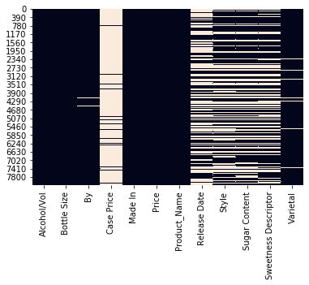

```python
#next lets check out the null or nan values in our data frame
print(wine.isnull().sum())
sns.heatmap(wine.isnull(), cbar=False)#Visual representation
```

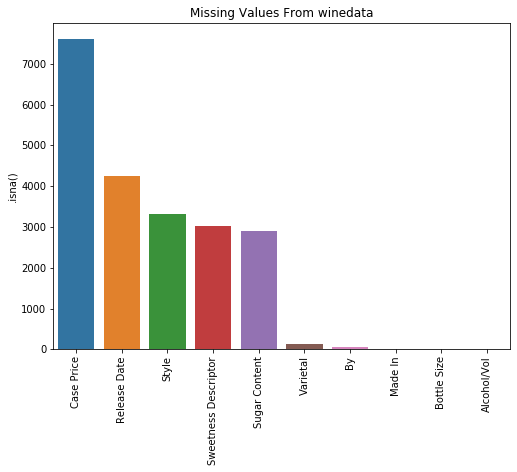

```python
def MissingValues(wine):
    plt.figure(figsize=(18,6))
    plt.subplot(1, 2, 1)
    MissingData=wine[wine.columns[wine.isnull().sum()>0]].isnull().sum().sort_values(ascending=False).to_frame()
    MissingData.columns = ['.isna()']
    MissingData['.isna()']
    p1=sns.barplot(x=MissingData.index, y='.isna()', data=MissingData)
    p1.set_xticklabels(p1.get_xticklabels(), rotation=90)
    p1.set_title('Missing Values From winedata')


MissingValues(wine)
```

### Lets check the missing values in Made In and Alcohol/Vol

```python
(wine[wine['Alcohol/Vol'].isnull()].index.tolist()) == (wine[wine['Made In'].isnull()].index.tolist())
wine[wine['Alcohol/Vol'].isnull()]
```

|  | Alcohol/Vol | Bottle Size | By | Case Price | Made In | Price | Product_Name | Release Date | Style | Sugar Content | Sweetness Descriptor | Varietal |
| --- | --- | --- | --- | --- | --- | --- | --- | --- | --- | --- | --- | --- |
| 442 | NaN | NaN | NaN | NaN | NaN | 15.85 | Calcu Reserva Especial Carmenère 2016 | NaN | NaN | NaN | NaN | NaN |
| 872 | NaN | NaN | NaN | NaN | NaN | 16.90 | Gaia 14-18h Agiorgitiko 2018 | NaN | NaN | NaN | NaN | NaN |
| 1099 | NaN | NaN | NaN | NaN | NaN | 17.15 | Gaia Monograph Moschofilero 2018 | NaN | NaN | NaN | NaN | NaN |
| 1103 | NaN | NaN | NaN | NaN | NaN | 17.15 | Gaia Monograph Agiorgitiko 2018 | NaN | NaN | NaN | NaN | NaN |
| 1110 | NaN | NaN | NaN | NaN | NaN | 17.20 | Cuvée Benkovac 2016 | NaN | NaN | NaN | NaN | NaN |
| 1288 | NaN | NaN | NaN | NaN | NaN | 17.95 | Château La Caminade Cahors 2011 | NaN | NaN | NaN | XD - Extra Dry | NaN |
| 1906 | NaN | NaN | NaN | NaN | NaN | 14.80 | Calcu Reserva Especial Semillon 2018 | NaN | NaN | NaN | NaN | NaN |
| 7849 | NaN | NaN | NaN | NaN | NaN | 3.45 | East Street Bottleworks Landmark Dry Cider | NaN | NaN | NaN | NaN | NaN |

#### We can see that they both point to the same index of our df and we could delete these values since they only show price and Product name

```python
print('We have {} terms missing everything but price and Product Name which represents {}% of our data'.format(len(wine[wine['Alcohol/Vol'].isnull()]),round(len(wine[wine['Alcohol/Vol'].isnull()])/len(wine)*100,4)))
```

```
We have 8 terms missing everything but price and Product Name which represents 0.0978% of our data
```

#### At less than .1% of our overall data we will delete these 8 wines as outliers from our data set and assume that theres a reason they wern't properly recorded on the website

```python
wine.drop(wine[wine['Alcohol/Vol'].isnull()].index.tolist(),axis=0,inplace=True)
wine.reset_index(drop=True,inplace=True)#reset index again
```

```python
print('Wine missing varietal=',len(wine[wine['Varietal'].isnull()].index.tolist()))
```

```
Wine missing varietal= 132
```

## Lets see if we can figure out some of these missing Varietals

```python
wine[pd.isnull(wine['Varietal'])].head()
```

|  | Alcohol/Vol | Bottle Size | By | Case Price | Made In | Price | Product_Name | Release Date | Style | Sugar Content | Sweetness Descriptor | Varietal |
| --- | --- | --- | --- | --- | --- | --- | --- | --- | --- | --- | --- | --- |
| 28 | 13.0 | 750 | Niepoort (Vinhos) S.A. | NaN | Douro, Portugal | 17.70 | Dialogo Tinto Hunter 2015 | NaN | NaN | NaN | NaN | NaN |
| 277 | 13.3 | 750 | Rustenberg Wine | NaN | South Africa | 14.95 | Rustenberg Stellenbosch Chenin Blanc | NaN | Light & Cri | 2.0 | NaN | NaN |
| 295 | 12.1 | 1500 | Colio Wines Of Canada Ltd. | NaN | Ontario, Canada | 14.95 | Colio Blush Rosé | NaN | Easygoing & Fruity | 19.0 | M - Medium | NaN |
| 364 | 11.5 | 750 | Winzerkeller Hex Vom Dasenstein Eg | NaN | Baden, Germany | 15.10 | Hex Vom Dasenstein Rivaner 2015 | NaN | NaN | NaN | NaN | NaN |
| 392 | 8.0 | 750 | Vina Casal De Gorsch | NaN | Chile | 15.25 | Fresita Sparkling Wine | NaN | Light & Fruity | 74.0 | S - Sweet | NaN |

### Now we can try to determine the varietal from the Product_Name. For example the "Rustenberg Stellenbosch Chenin Blanc" seen above is most likely a Chenin Blanc Varietal

### Before we do that though lets check for wines with same names

```python
NameMissingVariatel=wine[wine['Varietal'].isna()]['Product_Name']#  list of Wines missing a Varietal
CurrentVariatals=wine['Varietal'].unique().tolist()
CurrentVariatals = [x for x in CurrentVariatals if str(x) != 'nan']#need to remove nan values or [x for x in CurrentVariatals if pd.isnull(x)==False]
i=0
duplicates=[]

for n in NameMissingVariatel:   #Check to see if we already have a wine with the same name that doesnt have Varietal=NAN
            if n in wine[pd.isnull(wine['Varietal'])==False]['Product_Name'].tolist():
               duplicates.append(n)
                    #print(wine[wine['Product_Name']==n]['Varietal']).dropna()tolist()
print(duplicates)
```

```
['Manischewitz Concord K', 'Bodacious Smooth Red', "Girls' Night Out Sangria", 'Calvet Beaujolais Nouveau']
```

```python
for x in duplicates:
    print('{}:    {}'.format(x,wine[wine['Product_Name']==x]['Varietal'].tolist()))#shows what varietals we have for matching names
```

```
Manischewitz Concord K:    [nan, 'Red - Sweet']
Bodacious Smooth Red:    [nan, 'Red Table Wines (Unnamed Blends)', 'Red Blend']
Girls' Night Out Sangria:    [nan, 'Flavoured Wine']
Calvet Beaujolais Nouveau:    [nan, 'Gamay (Beaujolais)']
```

```python
DuplicateIndex=[]
for x in duplicates:
    for y in wine[(wine['Product_Name'])==x].index:
        DuplicateIndex.append(y)
wine.iloc[DuplicateIndex]
```

|  | Alcohol/Vol | Bottle Size | By | Case Price | Made In | Price | Product_Name | Release Date | Style | Sugar Content | Sweetness Descriptor | Varietal |
| --- | --- | --- | --- | --- | --- | --- | --- | --- | --- | --- | --- | --- |
| 1815 | 11.0 | 1500 | Constellation Brands Inc. (Us) | NaN | New York, USA | 14.55 | Manischewitz Concord K | April 3, 2019 | Medium-bodied & Fruity | 167.0 | S - Sweet | NaN |
| 8137 | 10.5 | 750 | Canandaigua Winery Naple | NaN | New York, USA | 8.00 | Manischewitz Concord K | April 3, 2019 | Medium-bodied & Fruity | 167.0 | NaN | Red - Sweet |
| 5431 | 12.5 | 4000mLbagnbox | Arterra Wines Canada, Inc. | NaN | Canada | 42.95 | Bodacious Smooth Red | NaN | Full-bodied & Smooth | 24.0 | M - Medium | NaN |
| 7986 | 12.5 | 250 | Arterra Wines Canada, Inc. | NaN | Ontario, Canada | 4.45 | Bodacious Smooth Red | NaN | Full-bodied & Smooth | 24.0 | M - Medium | Red Table Wines (Unnamed Blends) |
| 8047 | 12.5 | 750 | Arterra Wines Canada, Inc. | NaN | Canada | 9.95 | Bodacious Smooth Red | NaN | Full-bodied & Smooth | 24.0 | M - Medium | Red Blend |
| 7979 | 6.5 | 473 | Colio Wines Of Canada Ltd. | NaN | Ontario, Canada | 4.25 | Girls' Night Out Sangria | NaN | Crisp & Berry Fruit | 77.0 | S - Sweet | NaN |
| 8053 | 6.5 | 750 | Colio Wines Of Canada Ltd. | NaN | Ontario, Canada | 9.95 | Girls' Night Out Sangria | NaN | Crisp & Berry Fruit | 88.0 | S - Sweet | Flavoured Wine |
| 8021 | 12.0 | 750 | J. Calvet & Cie - Bordeaux | NaN | Beaujolais, France | 9.85 | Calvet Beaujolais Nouveau | NaN | NaN | NaN | NaN | NaN |
| 8115 | 12.5 | 750 | J. Calvet & Cie - Bordeaux | NaN | Burgundy, France | 7.95 | Calvet Beaujolais Nouveau | NaN | NaN | 2.0 | XD - Extra Dry | Gamay (Beaujolais) |

```python
# Now we can manually sub in the correct values for these or drop duplicates



ind=wine[((wine['Product_Name'])==duplicates[0]) & pd.isnull(wine['Varietal'])==True].index[0] #get index of wine for given Product_Name
wine.iloc[ind, wine.columns.get_loc('Varietal')] ='Red - Sweet' #replace varietal name with '   '

ind=wine[((wine['Product_Name'])==duplicates[1]) & pd.isnull(wine['Varietal'])==True].index[0]
wine.iloc[ind, wine.columns.get_loc('Varietal')] ='Red Blend'

ind=wine[((wine['Product_Name'])==duplicates[2]) & pd.isnull(wine['Varietal'])==True].index[0]
wine.iloc[ind, wine.columns.get_loc('Varietal')] ='Flavoured wine'

ind=wine[((wine['Product_Name'])==duplicates[3]) & pd.isnull(wine['Varietal'])==True].index
wine.iloc[ind, wine.columns.get_loc('Varietal')] ='Gamay (Beaujolais)'
```

```python
wine.iloc[DuplicateIndex]# Our fixed wines
```

|  | Alcohol/Vol | Bottle Size | By | Case Price | Made In | Price | Product_Name | Release Date | Style | Sugar Content | Sweetness Descriptor | Varietal |
| --- | --- | --- | --- | --- | --- | --- | --- | --- | --- | --- | --- | --- |
| 1815 | 11.0 | 1500 | Constellation Brands Inc. (Us) | NaN | New York, USA | 14.55 | Manischewitz Concord K | April 3, 2019 | Medium-bodied & Fruity | 167.0 | S - Sweet | Red - Sweet |
| 8137 | 10.5 | 750 | Canandaigua Winery Naple | NaN | New York, USA | 8.00 | Manischewitz Concord K | April 3, 2019 | Medium-bodied & Fruity | 167.0 | NaN | Red - Sweet |
| 5431 | 12.5 | 4000mLbagnbox | Arterra Wines Canada, Inc. | NaN | Canada | 42.95 | Bodacious Smooth Red | NaN | Full-bodied & Smooth | 24.0 | M - Medium | Red Blend |
| 7986 | 12.5 | 250 | Arterra Wines Canada, Inc. | NaN | Ontario, Canada | 4.45 | Bodacious Smooth Red | NaN | Full-bodied & Smooth | 24.0 | M - Medium | Red Table Wines (Unnamed Blends) |
| 8047 | 12.5 | 750 | Arterra Wines Canada, Inc. | NaN | Canada | 9.95 | Bodacious Smooth Red | NaN | Full-bodied & Smooth | 24.0 | M - Medium | Red Blend |
| 7979 | 6.5 | 473 | Colio Wines Of Canada Ltd. | NaN | Ontario, Canada | 4.25 | Girls' Night Out Sangria | NaN | Crisp & Berry Fruit | 77.0 | S - Sweet | Flavoured wine |
| 8053 | 6.5 | 750 | Colio Wines Of Canada Ltd. | NaN | Ontario, Canada | 9.95 | Girls' Night Out Sangria | NaN | Crisp & Berry Fruit | 88.0 | S - Sweet | Flavoured Wine |
| 8021 | 12.0 | 750 | J. Calvet & Cie - Bordeaux | NaN | Beaujolais, France | 9.85 | Calvet Beaujolais Nouveau | NaN | NaN | NaN | NaN | Gamay (Beaujolais) |
| 8115 | 12.5 | 750 | J. Calvet & Cie - Bordeaux | NaN | Burgundy, France | 7.95 | Calvet Beaujolais Nouveau | NaN | NaN | 2.0 | XD - Extra Dry | Gamay (Beaujolais) |

### Now we can take a look a our other wines missing Varietals

```python
print('\n {} wines still with NaN for Varietal'.format(wine['Varietal'].isna().sum()))
#MissingValues(wine)
```

```
 128 wines still with NaN for Varietal
```

```python
wine[pd.isnull(wine['Varietal'])].head()
```

|  | Alcohol/Vol | Bottle Size | By | Case Price | Made In | Price | Product_Name | Release Date | Style | Sugar Content | Sweetness Descriptor | Varietal |
| --- | --- | --- | --- | --- | --- | --- | --- | --- | --- | --- | --- | --- |
| 28 | 13.0 | 750 | Niepoort (Vinhos) S.A. | NaN | Douro, Portugal | 17.70 | Dialogo Tinto Hunter 2015 | NaN | NaN | NaN | NaN | NaN |
| 277 | 13.3 | 750 | Rustenberg Wine | NaN | South Africa | 14.95 | Rustenberg Stellenbosch Chenin Blanc | NaN | Light & Cri | 2.0 | NaN | NaN |
| 295 | 12.1 | 1500 | Colio Wines Of Canada Ltd. | NaN | Ontario, Canada | 14.95 | Colio Blush Rosé | NaN | Easygoing & Fruity | 19.0 | M - Medium | NaN |
| 364 | 11.5 | 750 | Winzerkeller Hex Vom Dasenstein Eg | NaN | Baden, Germany | 15.10 | Hex Vom Dasenstein Rivaner 2015 | NaN | NaN | NaN | NaN | NaN |
| 392 | 8.0 | 750 | Vina Casal De Gorsch | NaN | Chile | 15.25 | Fresita Sparkling Wine | NaN | Light & Fruity | 74.0 | S - Sweet | NaN |

### Now we can try to determine the varietal from the Product_Name

### For example the "Rustenberg Stellenbosch Chenin Blanc" seen above is most likely a Chenin Blanc Varietal

```python
#Replacing varietal given varietal in name

countmissingvarietal=wine['Varietal'].isna().sum()
FromTitle=[]
indx=[]
NameMissingVariatel=wine[wine['Varietal'].isna()]['Product_Name']# need to update list

for v in CurrentVariatals:
    for n in NameMissingVariatel:
         if v in n:
            FromTitle.append((wine[(wine['Product_Name'])==n].index[0]))
            wine.iloc[wine[(wine['Product_Name'])==n].index[0], wine.columns.get_loc('Varietal')] = v


print('we have filled in {} varietals and gone from {} wines with NaN for Varietal to {}'.format((countmissingvarietal-wine['Varietal'].isna().sum()),countmissingvarietal,wine['Varietal'].isna().sum()))
wine.iloc[FromTitle].head()
```

```
we have filled in 57 varietals and gone from 128 wines with NaN for Varietal to 71
```

|  | Alcohol/Vol | Bottle Size | By | Case Price | Made In | Price | Product_Name | Release Date | Style | Sugar Content | Sweetness Descriptor | Varietal |
| --- | --- | --- | --- | --- | --- | --- | --- | --- | --- | --- | --- | --- |
| 1214 | 14.0 | 750 | De Morgenzo | NaN | South Africa | 17.95 | DeMorgenzon DMZ Sauvignon Blanc | NaN | Aromatic & Flavourful | 7.0 | NaN | Sauvignon Blanc |
| 5735 | 13.5 | 4x750 | Lcbo | NaN | Chile | 48.00 | Santa Rita 120 Sauvignon Blanc Wine Special Offer | NaN | NaN | NaN | NaN | Sauvignon Blanc |
| 5198 | 13.0 | 2x750 | Tommasi | NaN | Venezie, Italy | 39.95 | Tommasi Graticcio 2016 & Pinot Grigio 2017 | October 27, 2018 | NaN | NaN | NaN | Pinot Gri |
| 7903 | 6.0 | 750 | Arterra Wines Canada, Inc. | NaN | Ontario, Canada | 8.95 | Cabana Shore Peach Pinot Grigio | NaN | NaN | 100.0 | S - Sweet | Pinot Gri |
| 1680 | 13.0 | 750 | Beaulieu Vineyard | NaN | California, USA | 13.95 | Beaulieu Vineyards Coastal Estates Cabernet Sa... | NaN | Full-bodied & Smooth | 8.0 | D - Dry | Cabernet Sauvigno |

```python
FromTitle=[]
for n in NameMissingVariatel:
        if 'Sangria' in n:
            for x in wine[(wine['Product_Name'])==n].index:# incase there are multiple wines with the same name
                    FromTitle.append(x)
                    wine.iloc[x, wine.columns.get_loc('Varietal')] = 'Flavoured wine'


wine.iloc[FromTitle]
```

|  | Alcohol/Vol | Bottle Size | By | Case Price | Made In | Price | Product_Name | Release Date | Style | Sugar Content | Sweetness Descriptor | Varietal |
| --- | --- | --- | --- | --- | --- | --- | --- | --- | --- | --- | --- | --- |
| 7841 | 6.9 | 473 | Societe De Vin Internationale | NaN | Quebec, Canada | 3.45 | Pepito Sangria | NaN | Crisp & Dark Fruit | 59.0 | S - Sweet | Flavoured wine |
| 7933 | 6.5 | 750 | Mastronardi Esatate Winery | NaN | Ontario, Canada | 9.05 | Mastronardi White Sangria | NaN | NaN | 87.0 | S - Sweet | Flavoured wine |
| 7980 | 6.5 | 473 | Colio Wines Of Canada Ltd. | NaN | Ontario, Canada | 4.25 | Girls' Night Out White Sangria | NaN | Crisp & Orchard Fruit | 85.0 | S - Sweet | Flavoured wine |
| 8075 | 6.8 | 750 | Colio Wines Of Canada Ltd. | NaN | Ontario, Canada | 9.95 | Girls' Night Out White Sangria | NaN | Crisp & Orchard Fruit | 85.0 | S - Sweet | Flavoured wine |
| 8065 | 11.0 | 750 | Andrew Peller Limited | NaN | Ontario, Canada | 9.95 | XOXO Red Sangria | NaN | Crisp & Berry Fruit | 60.0 | S - Sweet | Flavoured wine |
| 7980 | 6.5 | 473 | Colio Wines Of Canada Ltd. | NaN | Ontario, Canada | 4.25 | Girls' Night Out White Sangria | NaN | Crisp & Orchard Fruit | 85.0 | S - Sweet | Flavoured wine |
| 8075 | 6.8 | 750 | Colio Wines Of Canada Ltd. | NaN | Ontario, Canada | 9.95 | Girls' Night Out White Sangria | NaN | Crisp & Orchard Fruit | 85.0 | S - Sweet | Flavoured wine |
| 8079 | 7.5 | 750 | H. Schmitt Soehne | NaN | Spain | 5.85 | Funf 5 Sangria Spain | NaN | Medium-bodied & Fruity | 110.0 | S - Sweet | Flavoured wine |
| 8113 | 11.4 | 750 | Arterra Wines Canada, Inc. | NaN | Ontario, Canada | 7.75 | Naked Grape Sangria | NaN | Crisp & Berry Fruit | 47.0 | S - Sweet | Flavoured wine |
| 8135 | 7.0 | 750 | J. Garcia Carrion S.A. | NaN | Spain | 7.95 | Don Simon Sangria, Spain | NaN | Light-bodied & Fruity | 73.0 | S - Sweet | Flavoured wine |

```python
NameMissingVariatel=wine[wine['Varietal'].isna()]['Product_Name'] # update list of wines missing Varietal
wine.iloc[NameMissingVariatel.index]['Product_Name'].head()
```

```
28             Dialogo Tinto Hunter 2015
364      Hex Vom Dasenstein Rivaner 2015
485           Heritage Estate Apple Wine
830     Forbidden Fruit Pearsuasion 2013
1083          Highway 29 Strawberry Wine
Name: Product_Name, dtype: object
```

```python
wordlist=[]
words_in_names=[]
for x in wine[pd.isnull(wine['Varietal'])]['Product_Name']:
    for y in (x.split(' ')):#split into individual words
        wordlist.append(y)    #add each word into a list

tempdf=pd.DataFrame()
tempdf['words']=wordlist
words_in_names=tempdf['words'].value_counts()#look at repeats only
words_in_names.drop(['Wine','2015','2014','2013','&','Night','Hex','Special','The','de'])[0:8] #cleannames up the list to see usefull
```

```
Red           6
Girls'        3
Offer         3
Apple         3
Raspberry     3
Out           3
Dasenstein    2
Vom           2
Name: words, dtype: int64
```

### We can see a lot of fruit names in here

```python
FromTitle=[]
chosenwords=['Apple','Raspberry','Berries','Blueberry','Fruit','berry','Pear']
for n in NameMissingVariatel:
        if any(word in n for word in chosenwords ):
            FromTitle.append((wine[(wine['Product_Name'])==n].index[0]))
            wine.iloc[wine[(wine['Product_Name'])==n].index[0], wine.columns.get_loc('Varietal')] = 'Fruit wine'
           # print()

wine.iloc[FromTitle].head()
```

|  | Alcohol/Vol | Bottle Size | By | Case Price | Made In | Price | Product_Name | Release Date | Style | Sugar Content | Sweetness Descriptor | Varietal |
| --- | --- | --- | --- | --- | --- | --- | --- | --- | --- | --- | --- | --- |
| 485 | 10.0 | 750 | Heritage Estate Winery + Cider | NaN | Ontario, Canada | 15.95 | Heritage Estate Apple Wine | NaN | NaN | 34.0 | M - Medium | Fruit wine |
| 830 | 13.0 | 750 | Forbidden Fruit Winery | NaN | British Columbia, Canada | 16.75 | Forbidden Fruit Pearsuasion 2013 | March 5, 2016 | NaN | 25.0 | M - Medium | Fruit wine |
| 1083 | 10.6 | 750 | Needham's Market Garde | NaN | Ontario, Canada | 17.00 | Highway 29 Strawberry Wine | NaN | NaN | 136.0 | S - Sweet | Fruit wine |
| 2001 | 10.2 | 750 | Blueberry Hill Estate | NaN | Ontario, Canada | 15.45 | Blueberry Hill Estates Blueberry Wine | NaN | Dry | 4.0 | XD - Extra Dry | Fruit wine |
| 2677 | 10.0 | 750 | Markland Cottage Winery | NaN | Newfoundland, Canada | 20.65 | Sweet Berries Black Currant Wine | NaN | NaN | NaN | NaN | Fruit wine |

```python
NameMissingVariatel=wine[wine['Varietal'].isna()]['Product_Name'] # update list of wines missing Varietal
(wine.iloc[NameMissingVariatel.index]['Product_Name']).head()
```

```
28                         Dialogo Tinto Hunter 2015
364                  Hex Vom Dasenstein Rivaner 2015
1191                                 Atma White 2015
1330    Carnivor + FREE Weber Grill Online Exclusive
1334                    Taiheizan Kimoto Junmai Sake
Name: Product_Name, dtype: object
```

```python
wine[wine['Varietal'].isna()].head()
```

|  | Alcohol/Vol | Bottle Size | By | Case Price | Made In | Price | Product_Name | Release Date | Style | Sugar Content | Sweetness Descriptor | Varietal |
| --- | --- | --- | --- | --- | --- | --- | --- | --- | --- | --- | --- | --- |
| 28 | 13.0 | 750 | Niepoort (Vinhos) S.A. | NaN | Douro, Portugal | 17.70 | Dialogo Tinto Hunter 2015 | NaN | NaN | NaN | NaN | NaN |
| 364 | 11.5 | 750 | Winzerkeller Hex Vom Dasenstein Eg | NaN | Baden, Germany | 15.10 | Hex Vom Dasenstein Rivaner 2015 | NaN | NaN | NaN | NaN | NaN |
| 1191 | 13.0 | 750 | Thymiopoulos Apostolo | 214.2 | Greece | 17.85 | Atma White 2015 | NaN | NaN | NaN | NaN | NaN |
| 1330 | 14.0 | 750 | Lcbo | 215.4 | California, USA | 17.95 | Carnivor + FREE Weber Grill Online Exclusive | NaN | NaN | NaN | NaN | NaN |
| 1334 | 15.3 | 300 | Kodama Brewing Co., Ltd | NaN | Japan | 17.95 | Taiheizan Kimoto Junmai Sake | NaN | NaN | 17.0 | NaN | NaN |

```python
#We can see from looking at the Product Name that most of these wines missing both the Varietal and Bottle Size seem to be
#part of a gift set or promotional offer with one Bodacious Smooth Red looking to be a larger bag in the box type wine
#We will set all wines with +,& offer, Special, Gift, set, Online, Exclusive
NameMissingVariatel=wine[wine['Varietal'].isna()]['Product_Name'] # update list of wines missing Varietal
fixed_wine=[]
chosenwords=['+','&','offer','SPECIAL','OFFER', 'Special', 'Gift', 'set', 'Online', 'Exclusive','Kit']
for WINE in NameMissingVariatel:
        if any(word in WINE for word in chosenwords):
            for x in wine[(wine['Product_Name'])==WINE].index: #use for x in _ incase multiple wines with same name
                fixed_wine.append(x)
                wine.iloc[x, wine.columns.get_loc('Varietal')] = 'Gift Set/Special'
wine.iloc[fixed_wine].head()
```

|  | Alcohol/Vol | Bottle Size | By | Case Price | Made In | Price | Product_Name | Release Date | Style | Sugar Content | Sweetness Descriptor | Varietal |
| --- | --- | --- | --- | --- | --- | --- | --- | --- | --- | --- | --- | --- |
| 1330 | 14.0 | 750 | Lcbo | 215.4 | California, USA | 17.95 | Carnivor + FREE Weber Grill Online Exclusive | NaN | NaN | NaN | NaN | Gift Set/Special |
| 2331 | 14.0 | 2x750 | Distell | NaN | South Africa | 19.95 | Fleur Du Cap Duo Gift Pack | NaN | NaN | NaN | NaN | Gift Set/Special |
| 4287 | 14.9 | 750 | Permasur S | NaN | Argentina | 29.95 | The Owl & The Dust Devil | NaN | Full-bodied & Firm | 6.0 | NaN | Gift Set/Special |
| 5239 | 12.9 | 750 | David And Nadia (Pty) Ltd | NaN | South Africa | 39.95 | David & Nadia Aristargos | NaN | NaN | 5.0 | NaN | Gift Set/Special |
| 5419 | 13.0 | 6x565 | Lcbo | NaN | Ontario, Canada | 42.90 | D'Ont Poke The Bear Contest Special Offer | NaN | NaN | NaN | NaN | Gift Set/Special |

```python
NameMissingVariatel=wine[wine['Varietal'].isna()]['Product_Name'] # update list of wines missing Varietal
(wine[wine['Varietal'].isna()]).head()
```

|  | Alcohol/Vol | Bottle Size | By | Case Price | Made In | Price | Product_Name | Release Date | Style | Sugar Content | Sweetness Descriptor | Varietal |
| --- | --- | --- | --- | --- | --- | --- | --- | --- | --- | --- | --- | --- |
| 28 | 13.0 | 750 | Niepoort (Vinhos) S.A. | NaN | Douro, Portugal | 17.70 | Dialogo Tinto Hunter 2015 | NaN | NaN | NaN | NaN | NaN |
| 364 | 11.5 | 750 | Winzerkeller Hex Vom Dasenstein Eg | NaN | Baden, Germany | 15.10 | Hex Vom Dasenstein Rivaner 2015 | NaN | NaN | NaN | NaN | NaN |
| 1191 | 13.0 | 750 | Thymiopoulos Apostolo | 214.2 | Greece | 17.85 | Atma White 2015 | NaN | NaN | NaN | NaN | NaN |
| 1334 | 15.3 | 300 | Kodama Brewing Co., Ltd | NaN | Japan | 17.95 | Taiheizan Kimoto Junmai Sake | NaN | NaN | 17.0 | NaN | NaN |
| 1506 | 17.0 | 750 | S.E.G.M. Dubonnet International | NaN | Bordeaux, France | 18.85 | Lillet Rouge | April 3, 2019 | NaN | 77.0 | NaN | NaN |

## We have now gone from 140 wines missing Varietals down to 40 wines without Varietals

# We will asume these 40 as outliers and remove them from the dataframe

```python
wine.drop(wine[wine['Varietal'].isnull()].index.tolist(),axis=0,inplace=True)
wine.reset_index(drop=True, inplace=True)#must reset index after deleting from df
wine.isnull().sum()
```

```
Alcohol/Vol                0
Bottle Size                0
By                        36
Case Price              7571
Made In                    0
Price                      0
Product_Name               0
Release Date            4213
Style                   3274
Sugar Content           2874
Sweetness Descriptor    2979
Varietal                   0
dtype: int64
```

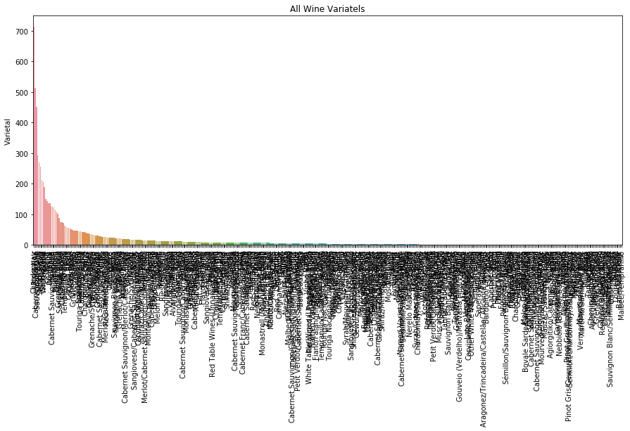

```python
WineVariatelCounts=wine['Varietal'].value_counts()
WineVariatels=wine['Varietal'].value_counts().index

plt.figure(figsize=(15,6))
p1=sns.barplot(x=WineVariatels, y=WineVariatelCounts)
p1.set_xticklabels(p1.get_xticklabels(), rotation=90)
p1.set_title('All Wine Variatels')
```

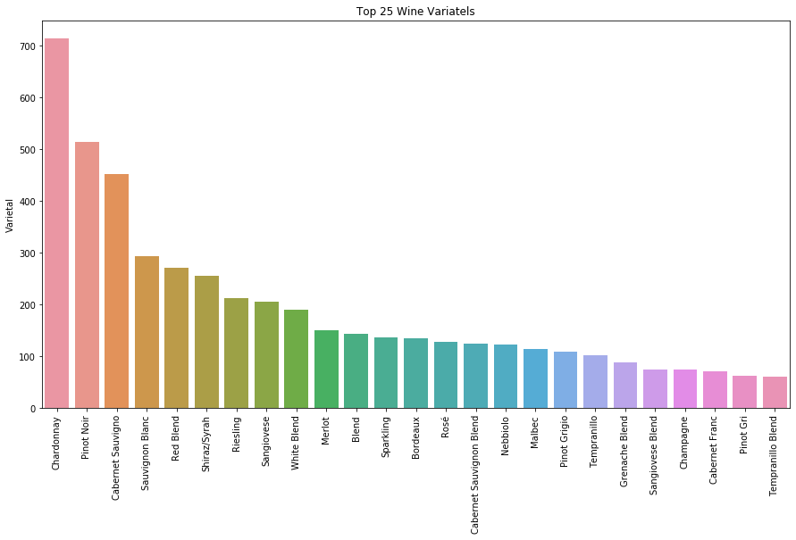

```python
plt.figure(figsize=(15,8))
p1=sns.barplot(x=WineVariatels[0:25], y=WineVariatelCounts[0:25])
p1.set_xticklabels(p1.get_xticklabels(), rotation=90)
p1.set_title('Top 25 Wine Variatels')
```

```python
wine[wine['By'].isna()].head()
```

|  | Alcohol/Vol | Bottle Size | By | Case Price | Made In | Price | Product_Name | Release Date | Style | Sugar Content | Sweetness Descriptor | Varietal |
| --- | --- | --- | --- | --- | --- | --- | --- | --- | --- | --- | --- | --- |
| 1749 | 14.0 | 750 | NaN | NaN | Languedoc, France | 14.20 | Bertrand Cabernet Sauvignon 2016 | NaN | NaN | NaN | NaN | Cabernet Sauvigno |
| 1959 | 12.5 | 750 | NaN | NaN | Utiel-Requena, Spain | 15.25 | Rebel.lia White Do Utiel-Requena 2017 | NaN | NaN | NaN | NaN | Chardonnay Blend |
| 2021 | 13.5 | 750 | NaN | NaN | Spain | 15.60 | Clos Dalian Garnacha Crianza 2015 | NaN | NaN | NaN | NaN | Grenache |
| 2022 | 13.0 | 750 | NaN | NaN | Spain | 15.60 | Clos Dalian Garnacha Blanca 2017 | NaN | NaN | NaN | NaN | Grenache Blanc |
| 2589 | 12.0 | 750 | NaN | NaN | Vinho Verde, Portugal | 20.20 | Aphros Loureiro White Vinho Verde 2009 | NaN | NaN | NaN | NaN | Loureiro |

```python
wine.isnull().sum()
```

```
Alcohol/Vol                0
Bottle Size                0
By                        36
Case Price              7571
Made In                    0
Price                      0
Product_Name               0
Release Date            4213
Style                   3274
Sugar Content           2874
Sweetness Descriptor    2979
Varietal                   0
dtype: int64
```

## I dont think we can reasonably clean anymore of these null Values so lets start looking at the data

# Now lets look at the region the wine was Made In

```python
print('First 20: ',wine['Made In'].unique()[0:20],'......')
print('\n nunique =',wine['Made In'].nunique()) #We have 239 different areas the wine was made in
```

```
First 20:  ['California, USA' 'USA' 'Dão, Portugal' 'Spain' 'Canada' 'Portugal'
 'Ontario, Canada' 'Languedoc, France' 'Friuli, Italy' 'South Africa'
 'Greece' 'Colchagua Valley, Chile' 'Penedès, Spain' 'Veneto, Italy'
 'Germany' 'Roussillon, France' 'Ribera del Duero, Spain'
 'Rias Baixas, Spain' 'Douro, Portugal' 'Provence, France'] ......

 nunique = 239
```

```python
#Lets see if we can simplify this a bit
(wine.iloc[27])['Made In']   #Region,Country
```

```
'Rias Baixas, Spain'
```

```python
wineLocation=wine['Made In'].fillna('Unknown')# change nan to string type so we can use our apply(split)
SplitMadein=wineLocation.apply(lambda x: x.split(','))

L1=[]
L2=[]
i=0
x=0
while i<len(SplitMadein):
    if len(SplitMadein[x])>1: # if we have a region and country
        L1.append(SplitMadein[x][0].replace(' ', '')) #need the .replace(' ', '') because we have... 'Germany' and ' Germany'.
        L2.append(SplitMadein[x][1].replace(' ', ''))
    else:
        L1.append(np.nan) # if we only have one identifying location
        L2.append(SplitMadein[x][0].replace(' ', ''))
    x+=1
    i+=1
Region=L1
Country=L2
wine['Region']=Region
wine['Country']=Country
wine.head()
```

|  | Alcohol/Vol | Bottle Size | By | Case Price | Made In | Price | Product_Name | Release Date | Style | Sugar Content | Sweetness Descriptor | Varietal | Region | Country |
| --- | --- | --- | --- | --- | --- | --- | --- | --- | --- | --- | --- | --- | --- | --- |
| 0 | 13.5 | 750 | Beringer Vineyard | NaN | California, USA | 17.45 | Beringer Founders' Estate Sauvignon Blanc | NaN | Light & Cri | 5.0 | XD - Extra Dry | Sauvignon Blanc | California | USA |
| 1 | 12.5 | 750 | Beringer Vineyard | NaN | USA | 17.45 | Beringer Founders' Estate Pinot Grigio | NaN | Light & Cri | 9.0 | D - Dry | Pinot Grigio | NaN | USA |
| 2 | 13.5 | 750 | Sociedade Agricola Faldas Da S | 209.4 | Dão, Portugal | 17.45 | Maias Red | NaN | NaN | NaN | NaN | Touriga Nacional Blend | Dão | Portugal |
| 3 | 13.5 | 750 | Robert Mondavi Winery | NaN | California, USA | 17.45 | Robert Mondavi Private Selection Sauvignon Blanc | NaN | Light & Cri | 6.0 | XD - Extra Dry | Sauvignon Blanc | California | USA |
| 4 | 12.5 | 750 | Bodegas Peique Sl | NaN | Spain | 17.45 | Peique Rosado Mencia Bierzo 2017 | NaN | NaN | NaN | NaN | Menci | NaN | Spain |

```python
wine['Region'].nunique()
```

```
203
```

```python
print(wine['Country'].nunique())
wine['Country'].unique()
```

```
38
```

```
array(['USA', 'Portugal', 'Spain', 'Canada', 'France', 'Italy',
       'SouthAfrica', 'Greece', 'Chile', 'Germany', 'Austria',
       'Australia', 'India', 'Argentina', 'Israel', 'NewZealand',
       'Georgia', 'Bulgaria', 'Hungary', 'Croatia', 'Jamaica',
       'RepublicofMoldova', 'Poland', 'Armenia', 'Ukraine', 'Romania',
       'Lebanon', 'Uruguay', 'Kosovo', 'Mexico', 'Luxembourg', 'Japan',
       'Slovakia', 'Cyprus', 'CzechRepublic', 'Slovenia', 'UnitedKingdom',
       'Serbia'], dtype=object)
```

```python
wine['Country'].unique()
Country=wine['Country'].value_counts()
Region=wine['Region'].value_counts()
Country[0:20]
```

```
France           1709
Italy            1537
USA              1015
Canada            909
Spain             516
Australia         500
Portugal          430
Chile             265
Argentina         243
NewZealand        202
Greece            197
SouthAfrica       172
Germany           156
Austria           126
Israel             42
Georgia            21
Hungary            20
UnitedKingdom       8
Ukraine             8
Bulgaria            7
Name: Country, dtype: int64
```

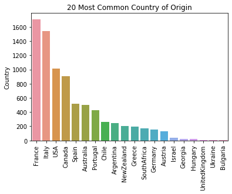

```python
C=sns.barplot(x=Country.index[0:20], y=Country[0:20])
C.set_xticklabels(C.get_xticklabels(), rotation=90)
C.set_title('20 Most Common Country of Origin')
```

```python
data = dict(type= 'choropleth', locations=wine.Country.value_counts().index, colorscale='speed',#color =speed or portland
          #reversescale=True,
          locationmode = 'country names',
          z=wine.Country.value_counts(),
          text=wine.Country.value_counts().index, colorbar={'title':'Quantity of Products'})
```

```python
layout=dict(title='Wined Sold in Ontario by Country of Origin' ,height=700,width=900, geo=dict(showframe=False,
           projection={'type':'mercator'}))#scope='europe'
```

```python
choromap=go.Figure(data=[data],layout=layout)
from plotly.offline import init_notebook_mode,iplot
init_notebook_mode(connected=True)
iplot(choromap,validate=False)
```

[interactive chart not shown]

```python
layout=dict(title='Wined Sold in Ontario by Country of Origin (Europe Close up)' ,height=700,width=900, geo=dict(showframe=False,
           projection={'type':'mercator'},scope='europe'))#

choromap=go.Figure(data=[data],layout=layout)
from plotly.offline import init_notebook_mode,iplot
init_notebook_mode(connected=True)
iplot(choromap,validate=False)
```

[interactive chart not shown]

### Now we can look at the bottle size

```python
wine['Bottle Size'].isna().sum()
```

```
0
```

```python
##Lets look at the bottle size
wine['Bottle Size'].unique()
```

```
array(['750', '1500', '375', '1000', '3x200', '500', '4x375', '750mLgift',
       '500mLgift', '2000', '200', '2x750', '3000mLbagnbox', '720',
       '3000', '200mLgift', '375mLgift', '4000mLbagnbox', '6x565',
       '4x750', '6x125', '4x781', '2x100', '2x200', '620', '2x375',
       '6x750', '5000', '5x200', '12x750', '8x750', '250', '473', '50',
       '300', '187'], dtype=object)
```

```python
# first we have to take care of the non integer bottle sizes
wine['BottleCategorical'] = wine['Bottle Size']
nonints=[]
for c in wine['Bottle Size'].unique().tolist():
    try: int(c) #test if value is an int
    except:nonints.append(c) #if not an int add to our non integer list

wine['BottleCategorical']=wine['BottleCategorical'].replace(nonints, 0)# Temporarily set nonints to 0 for casting
wine['BottleCategorical']=wine['BottleCategorical'].astype(float)# cast to float
wine['BottleCategorical'].unique()
```

```
array([ 750., 1500.,  375., 1000.,    0.,  500., 2000.,  200.,  720.,
       3000.,  620., 5000.,  250.,  473.,   50.,  300.,  187.])
```

```python
#lets create a categorical bottle size column
def func(x):
    if 0 < x <=749:
        return 'Small :<750ml'
    elif 749 < x <= 751:
        return 'Normal :750ml'
    elif 751 < x <= 1500:
            return 'Large :>750ml'
    elif 1501 < x <= 5000:
            return 'X-Large :>1500ml'
    elif x==0: #recall from above that 0 values were 2x750', '3000mLbagnbox', ' '375mLgift', '4000mLbagnbox.... etc
        return 'Unique(Box/Gift Pack)'

wine['BottleCategorical'] = wine['BottleCategorical'].apply(func)
```

```python
wine['BottleCategorical'].describe()
wine['BottleCategorical'].value_counts()
```

```
Normal :750ml            7530
Small :<750ml             248
Large :>750ml             244
Unique(Box/Gift Pack)      97
X-Large :>1500ml           15
Name: BottleCategorical, dtype: int64
```

## Part 2) Correlation Matrix and Exploration

## Although correlation does not imply causation lets take a look at some of these and do some correlation plots and see what has a positive and negative Correlation on Price

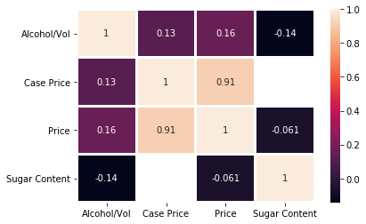

```python
sns.heatmap(wine.corr(),annot=True,linecolor='white',linewidths=2)
```

### We can see from above there is a slight correlation between Alcohol/Vol and Price this makes sense as a wine with a weak alcohol level might not sell as well.

### There is also the obvious correlation between Price and Case Price

|  | Price | Varietal_Pinot Noir | Varietal_Champagne | Varietal_Bordeaux | Varietal_Sauterne | Varietal_Nebbiolo | Varietal_Cabernet Sauvignon Blend |
| --- | --- | --- | --- | --- | --- | --- | --- |
| Price | 1.000000 | 0.134220 | 0.117341 | 0.113037 | 0.097065 | 0.091115 | 0.090327 |
| Varietal_Pinot Noir | 0.134220 | 1.000000 | -0.024886 | -0.033867 | -0.008644 | -0.032182 | -0.032315 |
| Varietal_Champagne | 0.117341 | -0.024886 | 1.000000 | -0.012495 | -0.003189 | -0.011873 | -0.011922 |
| Varietal_Bordeaux | 0.113037 | -0.033867 | -0.012495 | 1.000000 | -0.004340 | -0.016158 | -0.016225 |
| Varietal_Sauterne | 0.097065 | -0.008644 | -0.003189 | -0.004340 | 1.000000 | -0.004124 | -0.004141 |
| Varietal_Nebbiolo | 0.091115 | -0.032182 | -0.011873 | -0.016158 | -0.004124 | 1.000000 | -0.015417 |
| Varietal_Cabernet Sauvignon Blend | 0.090327 | -0.032315 | -0.011922 | -0.016225 | -0.004141 | -0.015417 | 1.000000 |

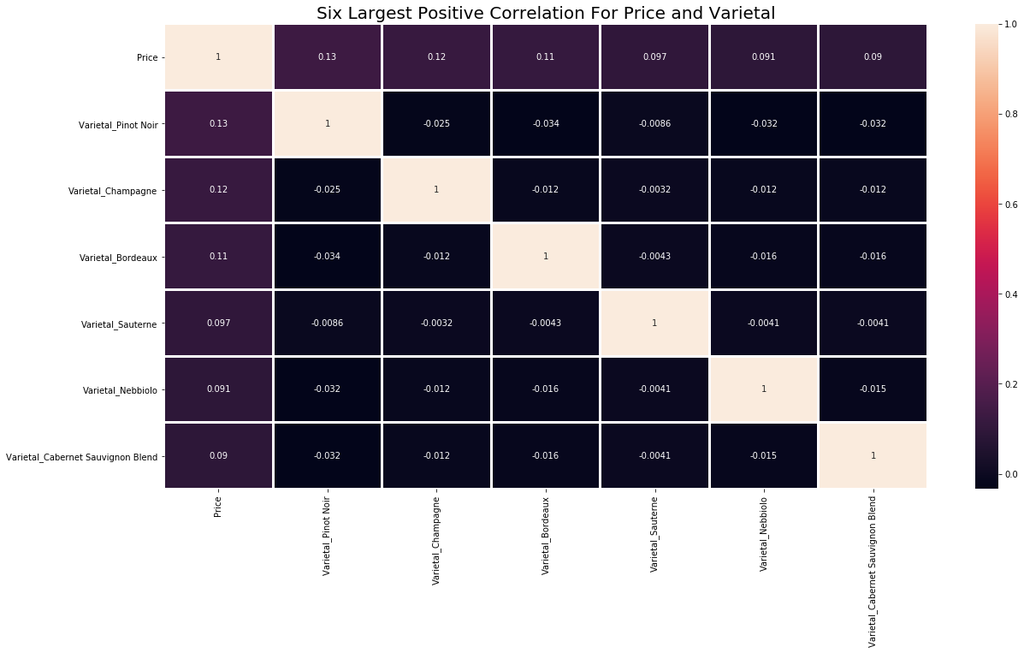

```python
wine_dummies = pd.get_dummies(wine, columns=['Varietal'],drop_first=False)
plt.figure(figsize=(20, 10))
highest=wine_dummies.corr().drop(['Case Price','Alcohol/Vol']).nlargest(7,columns='Price').index ##7 largest since price is one of them
sns.heatmap(wine_dummies[highest].corr(),linecolor='white',linewidths=2,annot=True).set_title('Six Largest Positive Correlation For Price and Varietal', fontsize=20)
wine_dummies[highest].corr()
```

### We can see above it looks like varietals like Pinot, Champagne, and Bordeaux are positively correlated with price. This could be due to higher costs needed to produce the wine or due to increased value given to well known wines like Champagne or Bordeaux

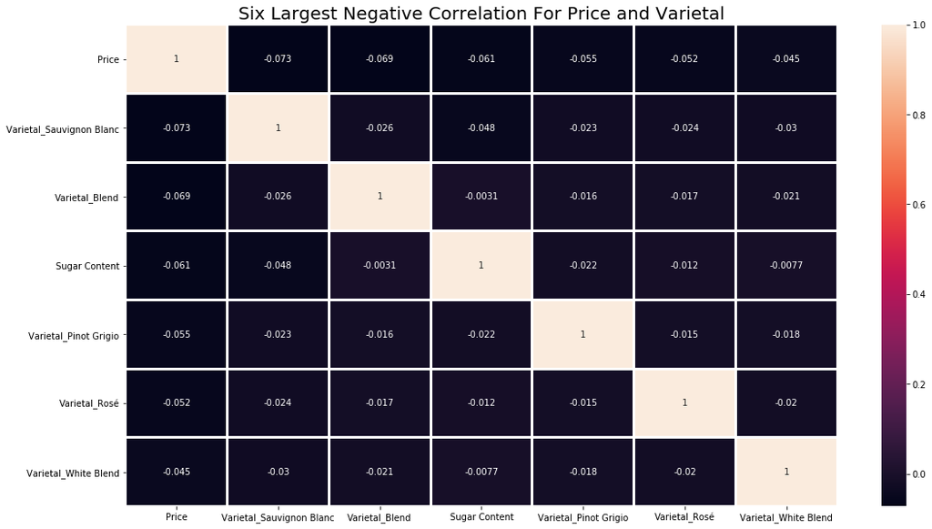

```python
plt.figure(figsize=(18, 10))
lowest=wine_dummies.corr().nsmallest(6,columns='Price').index.insert(0,'Price')
sns.heatmap(wine_dummies[lowest].corr(),linecolor='white',linewidths=2,annot=True).set_title('Six Largest Negative Correlation For Price and Varietal', fontsize=20)
```

### We can see above wines that are easier to make or lower quality mass produced wines like blends and Rose have a negative Correlation with Price

```python
# Method for making Correlation plots
def winecorrplot(data=wine,dummies=x,highest=None,lowest=None,poi=None):
    wine_dummies = pd.get_dummies(data, columns=[dummies],drop_first=False)
    plt.figure(figsize=(20, 10))
    if highest==True: #select nlargest
        highest=wine_dummies.corr().nlargest(5,columns=poi).index
        sns.heatmap(wine_dummies[highest].corr(),linecolor='white',linewidths=2,annot=True).set_title('Corr Matrix for '+poi+' and '+dummies+' (Highest)', fontsize=20)

    else: pass
    if lowest==True: #select nsmallest
        lowest=wine_dummies.corr().nsmallest(6,columns=poi).index.insert(0,poi)
        sns.heatmap(wine_dummies[lowest].corr(),linecolor='white',linewidths=2,annot=True).set_title('Corr Matrix for '+poi+' and '+dummies+' (Lowest)', fontsize=20)
    else:pass
```

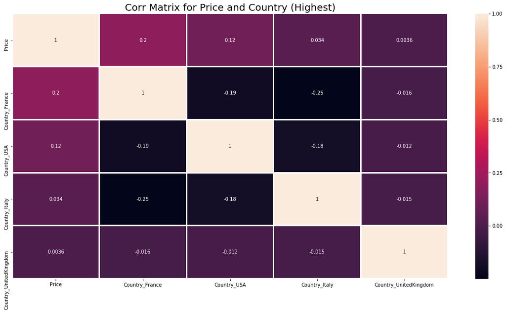

```python
winecorrplot(data=wine.drop(['Case Price','Alcohol/Vol'],axis=1),dummies='Country',highest=True,poi='Price')
```

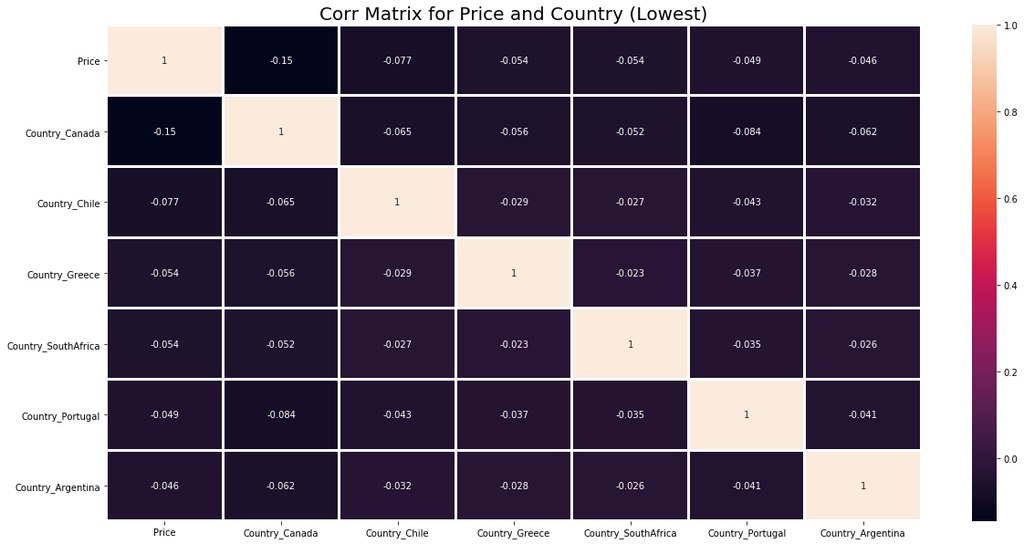

```python
winecorrplot(data=wine.drop(['Case Price','Alcohol/Vol','Sugar Content'],axis=1),dummies='Country',lowest=True,poi='Price')
```

### Above on the top plot we can see wines from France, USA, and Italy are positively correlated with price. This could be due to tariffs and the reputation wine from these countries have. On the other plot we can see wines from Canada have no added tariff or large transport costs and wines from the other countries like Chile and South Africa have a reputation of being cheaper and lower quality

### Lets see if we can get all these variablesrelated to price grouped together

```python
positive_corr=[]
interests=['Varietal','Country','Alcohol/Vol','Style','Sugar Content','Sweetness Descriptor']# What we want dummy variables of
for d in interests:
    wine_dummies = pd.get_dummies(wine, columns=[d],drop_first=False)# need dummies since not all are catagorical number
    highest=wine_dummies.corr()
    for x in ['Case Price','Alcohol/Vol','Sugar Content']: #drop these to prevent them from appearing in other corr.
        try: highest=highest.drop([x])
        except:pass
    highest=highest[highest>0].nlargest(11,columns='Price').index#positive correlation values only
    positive_corr.append(wine_dummies[highest].corr()['Price'])
#positive_corr

negative_corr=[]
#interest=['Varietal','Country','Alcohol/Vol','Style','Sugar Content','Sweetness Descriptor']
for d in interests:
    wine_dummies = pd.get_dummies(wine, columns=[d],drop_first=False,prefix=[' '])# need dummies since not all are a catagorical number
    negative=wine_dummies.corr()
    for x in ['Case Price','Alcohol/Vol','Sugar Content']:
        try:
            negative=negative.drop(x)
        except:pass
    negative=negative[negative<0].nsmallest(11,columns='Price').index.insert(0,'Price')# negative corr values only
    negative_corr.append(wine_dummies[negative].corr()['Price'])
# negative_corr
```

```python
positive_corr[0:2]
```

```
[Price                                1.000000
 Varietal_Pinot Noir                  0.134220
 Varietal_Champagne                   0.117341
 Varietal_Bordeaux                    0.113037
 Varietal_Sauterne                    0.097065
 Varietal_Nebbiolo                    0.091115
 Varietal_Cabernet Sauvignon Blend    0.090327
 Varietal_Sangiovese/Merlot           0.068611
 Varietal_White - Sweet               0.062541
 Varietal_Bordeaux Red                0.062134
 Varietal_Montepulciano/Sangiovese    0.059964
 Name: Price, dtype: float64, Price                    1.000000
 Country_France           0.195687
 Country_USA              0.116635
 Country_Italy            0.034229
 Country_UnitedKingdom    0.003606
 Country_Slovenia         0.002180
 Country_Cyprus           0.000651
 Name: Price, dtype: float64]
```

### Lets plot these all together

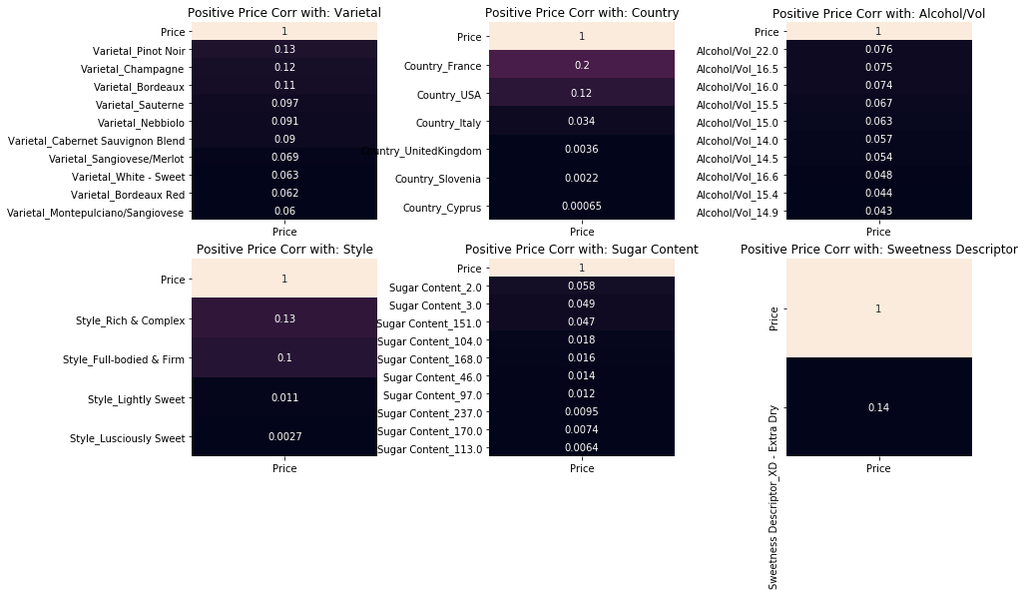

```python
plt.figure(figsize=(14,8))

plt.subplot(2, 3, 1)#top row
p1=sns.heatmap(pd.DataFrame(positive_corr[0]), annot=True,cbar=False).set_title('Positive Price Corr with: '+interests[0])

plt.subplot(2, 3, 2)
p2=sns.heatmap(pd.DataFrame(positive_corr[1]), annot=True,cbar=False).set_title('Positive Price Corr with: '+interests[1])

plt.subplot(2, 3, 3)
p3=sns.heatmap(pd.DataFrame(positive_corr[2]), annot=True,cbar=False).set_title('Positive Price Corr with: '+interests[2])


plt.subplot(2, 3, 4)#bottom row
p1=sns.heatmap(pd.DataFrame(positive_corr[3]), annot=True,cbar=False).set_title('Positive Price Corr with: '+interests[3])

plt.subplot(2, 3, 5)
p2=sns.heatmap(pd.DataFrame(positive_corr[4]), annot=True,cbar=False).set_title('Positive Price Corr with: '+interests[4])

plt.subplot(2, 3, 6)
p3=sns.heatmap(pd.DataFrame(positive_corr[5]), annot=True,cbar=False).set_title('Positive Price Corr with: '+interests[5])


plt.subplots_adjust(wspace=0.6)
```

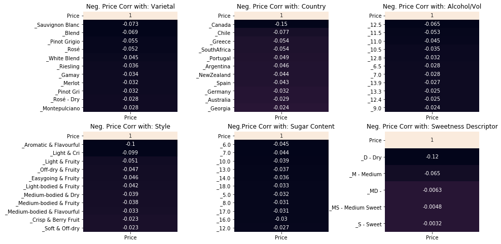

```python
plt.figure(figsize=(14,8))

plt.subplot(2, 3, 1)#top row
p1=sns.heatmap(pd.DataFrame(negative_corr[0]), annot=True,cbar=False).set_title('Neg. Price Corr with: '+interests[0])

plt.subplot(2, 3, 2)
p2=sns.heatmap(pd.DataFrame(negative_corr[1]), annot=True,cbar=False).set_title('Neg. Price Corr with: '+interests[1])

plt.subplot(2, 3, 3)
p3=sns.heatmap(pd.DataFrame(negative_corr[2]), annot=True,cbar=False).set_title('Neg. Price Corr with: '+interests[2])


plt.subplot(2, 3, 4)#bottom row
p1=sns.heatmap(pd.DataFrame(negative_corr[3]), annot=True,cbar=False).set_title('Neg. Price Corr with: '+interests[3])

plt.subplot(2, 3, 5)
p2=sns.heatmap(pd.DataFrame(negative_corr[4]), annot=True,cbar=False).set_title('Neg.Price Corr with: '+interests[4])

plt.subplot(2, 3, 6)
p3=sns.heatmap(pd.DataFrame(negative_corr[5]), annot=True,cbar=False).set_title('Neg. Price Corr with: '+interests[5])


plt.subplots_adjust(wspace=0.6)
```

# Part-3

### Now lets do some data aggregation with pivot tables and the group by method

```python
top10=wine['Varietal'].value_counts()[0:10].index#get most common ten wines
pivot_varietal_count=wine[['Varietal','BottleCategorical']].pivot_table(index='BottleCategorical',columns='Varietal',aggfunc=lambda x:x.count()).T
pivot_varietal_count.index # MultiIndex(levels=[['BottleCategorical', 'Varietal'], ['Agiorgitiko', 'Agiorgitiko(St.George)',.....
pivot_varietal_count.loc['Varietal'].loc[top10]
```

| BottleCategorical | Large :>750ml | Normal :750ml | Small :<750ml | Unique(Box/Gift Pack) | X-Large :>1500ml |
| --- | --- | --- | --- | --- | --- |
| Chardonnay | 19.0 | 685.0 | 4.0 | 6.0 | NaN |
| Pinot Noir | 1.0 | 510.0 | 1.0 | NaN | 2.0 |
| Cabernet Sauvigno | 20.0 | 423.0 | 6.0 | 3.0 | NaN |
| Sauvignon Blanc | 5.0 | 278.0 | 7.0 | 4.0 | NaN |
| Red Blend | 3.0 | 262.0 | 1.0 | 4.0 | 1.0 |
| Shiraz/Syrah | 5.0 | 245.0 | 3.0 | 3.0 | NaN |
| Riesling | 2.0 | 200.0 | 10.0 | 1.0 | NaN |
| Sangiovese | 7.0 | 193.0 | 5.0 | 1.0 | NaN |
| White Blend | 5.0 | 178.0 | 5.0 | 2.0 | NaN |
| Merlot | 10.0 | 138.0 | NaN | 3.0 | NaN |

```python
wine.groupby(['Varietal']).agg({np.mean, max, min}).loc[top10]
```

|  | Alcohol/Vol mean | Alcohol/Vol max | Alcohol/Vol min | Case Price mean | Case Price max | Case Price min | Price mean | Price max | Price min | Sugar Content mean | Sugar Content max | Sugar Content min |
| --- | --- | --- | --- | --- | --- | --- | --- | --- | --- | --- | --- | --- |
| Chardonnay | 13.267927 | 16.0 | 10.5 | 500.600000 | 1512.6 | 155.7 | 44.771709 | 326.00 | 3.60 | 4.144954 | 22.0 | 2.0 |
| Pinot Noir | 13.311479 | 15.4 | 11.0 | 626.537500 | 2275.8 | 174.3 | 72.050778 | 415.00 | 8.25 | 3.652819 | 13.0 | 2.0 |
| Cabernet Sauvigno | 13.991350 | 21.5 | 10.0 | 377.285000 | 1299.6 | 86.5 | 57.193142 | 415.00 | 8.00 | 6.149296 | 236.0 | 2.0 |
| Sauvignon Blanc | 12.897279 | 14.5 | 9.0 | 255.083333 | 449.4 | 89.1 | 25.115646 | 240.00 | 7.00 | 5.149038 | 146.0 | 2.0 |
| Red Blend | 13.899631 | 20.0 | 11.0 | 265.650000 | 655.8 | 55.8 | 40.940037 | 395.00 | 3.10 | 7.239130 | 39.0 | 2.0 |
| Shiraz/Syrah | 14.010938 | 16.1 | 11.9 | 352.700000 | 562.8 | 149.7 | 53.590234 | 399.00 | 4.95 | 4.448864 | 13.0 | 2.0 |
| Riesling | 11.327465 | 14.0 | 7.0 | 338.175000 | 663.6 | 130.5 | 33.397653 | 154.35 | 4.90 | 21.969925 | 173.0 | 2.0 |
| Sangiovese | 13.913592 | 19.0 | 9.5 | 317.957143 | 694.2 | 205.8 | 60.313835 | 334.15 | 7.95 | 3.746032 | 12.0 | 2.0 |
| White Blend | 12.618421 | 19.5 | 6.0 | 200.221154 | 542.7 | 90.3 | 29.471579 | 120.65 | 3.10 | 9.727273 | 29.0 | 2.0 |
| Merlot | 13.517219 | 16.3 | 11.5 | 319.740000 | 650.4 | 186.0 | 32.557285 | 276.00 | 7.95 | 5.673684 | 14.0 | 2.0 |

### Min Max Mean-Aggregated by Country

```python
agg_country=wine.groupby(['Country']).agg({np.mean, max, min}).loc[wine['Country'].value_counts()[0:10].index]# select ten most common
agg_country
```

|  | Alcohol/Vol mean | Alcohol/Vol max | Alcohol/Vol min | Case Price mean | Case Price max | Case Price min | Price mean | Price max | Price min | Sugar Content mean | Sugar Content max | Sugar Content min |
| --- | --- | --- | --- | --- | --- | --- | --- | --- | --- | --- | --- | --- |
| France | 13.174108 | 18.0 | 7.5 | 446.577108 | 2275.8 | 117.6 | 64.825453 | 420.00 | 4.95 | 7.604074 | 168.0 | 2.0 |
| Italy | 13.433897 | 50.0 | 5.0 | 400.174820 | 2163.0 | 86.5 | 48.597723 | 400.00 | 4.95 | 8.718570 | 218.0 | 2.0 |
| USA | 13.823074 | 17.2 | 5.5 | 574.991667 | 1663.5 | 202.8 | 61.115271 | 415.00 | 3.45 | 7.963548 | 176.0 | 2.0 |
| Canada | 12.328141 | 21.5 | 5.0 | 99.000000 | 99.0 | 99.0 | 23.328603 | 158.10 | 3.10 | 26.097926 | 276.0 | 2.0 |
| Spain | 13.669884 | 22.0 | 5.5 | 271.065517 | 741.9 | 99.0 | 36.236822 | 415.95 | 4.80 | 10.844106 | 183.0 | 2.0 |
| Australia | 13.618600 | 17.5 | 6.5 | 417.708000 | 654.0 | 186.6 | 38.814800 | 399.00 | 3.95 | 6.014663 | 204.0 | 2.0 |
| Portugal | 14.845209 | 21.0 | 9.0 | 243.730734 | 1294.2 | 55.8 | 33.856279 | 380.00 | 6.55 | 42.794326 | 141.0 | 2.0 |
| Chile | 13.567925 | 15.1 | 8.0 | 181.500000 | 298.2 | 99.0 | 22.924528 | 225.00 | 6.00 | 4.457895 | 74.0 | 2.0 |
| Argentina | 13.905926 | 15.7 | 10.0 | 233.280000 | 279.3 | 195.6 | 31.186831 | 345.00 | 7.95 | 3.916230 | 11.0 | 2.0 |
| NewZealand | 12.986139 | 14.5 | 9.0 | 301.895455 | 500.4 | 149.7 | 30.226733 | 159.60 | 4.90 | 5.366412 | 37.0 | 2.0 |

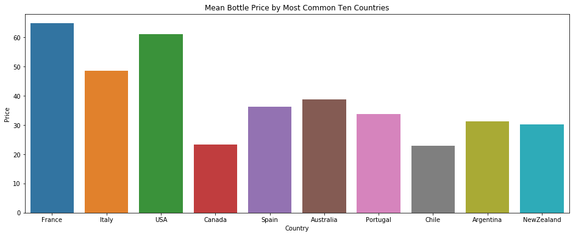

```python
# Here we will group the data, aggregate, then plot the mean
plt.figure(figsize=(16,6))
agg_country_mean=agg_country.T.loc['Price'].loc['mean']
sns.barplot(x=agg_country_mean.index, y=agg_country_mean.values).set_title('Mean Bottle Price by Most Common Ten Countries')
plt.ylabel("Price")
plt.xlabel("Country")
```

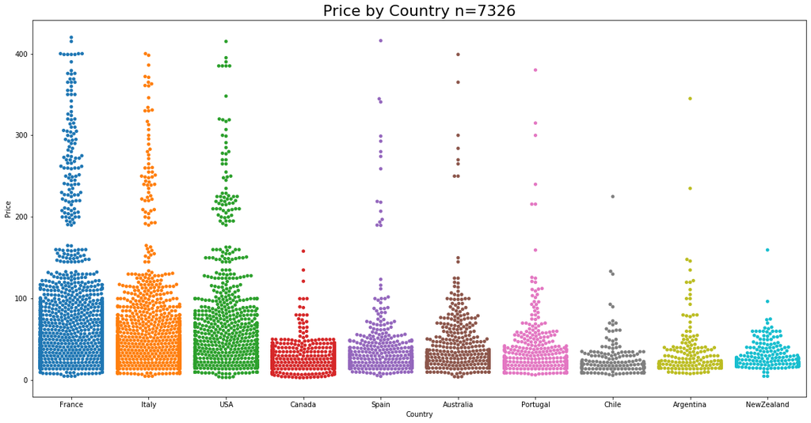

```python
plt.figure(figsize=(20, 10))
data=wine[wine['Country'].isin(agg_country_mean.index)]
sns.swarmplot(y='Price',x='Country',data=data,order=agg_country_mean.index)#use order= to plot same order as above
plt.title('Price by Country n={}'.format(len(data)) , fontsize=22)
```

### Lets take a look at bottle size

```python
#or with piovot tables
pivot_bottle_count=wine[['Product_Name','BottleCategorical']].pivot_table(index='BottleCategorical',aggfunc=lambda x:x.count()).T
pivot_bottle_count
```

| BottleCategorical | Large :>750ml | Normal :750ml | Small :<750ml | Unique(Box/Gift Pack) | X-Large :>1500ml |
| --- | --- | --- | --- | --- | --- |
| Product_Name | 244 | 7530 | 248 | 97 | 15 |

```python
top10=wine['Varietal'].value_counts()[0:10].index#get most common ten wines
pivot_varietal_count=wine[['Varietal','BottleCategorical']].pivot_table(index='BottleCategorical',columns='Varietal',aggfunc=lambda x:x.count()).T
pivot_varietal_count.index # MultiIndex(levels=[['BottleCategorical', 'Varietal'], ['Agiorgitiko', 'Agiorgitiko(St.George)',.....
pivot_varietal_count.loc['Varietal'].loc[top10]
```

| BottleCategorical | Large :>750ml | Normal :750ml | Small :<750ml | Unique(Box/Gift Pack) | X-Large :>1500ml |
| --- | --- | --- | --- | --- | --- |
| Chardonnay | 19.0 | 685.0 | 4.0 | 6.0 | NaN |
| Pinot Noir | 1.0 | 510.0 | 1.0 | NaN | 2.0 |
| Cabernet Sauvigno | 20.0 | 423.0 | 6.0 | 3.0 | NaN |
| Sauvignon Blanc | 5.0 | 278.0 | 7.0 | 4.0 | NaN |
| Red Blend | 3.0 | 262.0 | 1.0 | 4.0 | 1.0 |
| Shiraz/Syrah | 5.0 | 245.0 | 3.0 | 3.0 | NaN |
| Riesling | 2.0 | 200.0 | 10.0 | 1.0 | NaN |
| Sangiovese | 7.0 | 193.0 | 5.0 | 1.0 | NaN |
| White Blend | 5.0 | 178.0 | 5.0 | 2.0 | NaN |
| Merlot | 10.0 | 138.0 | NaN | 3.0 | NaN |

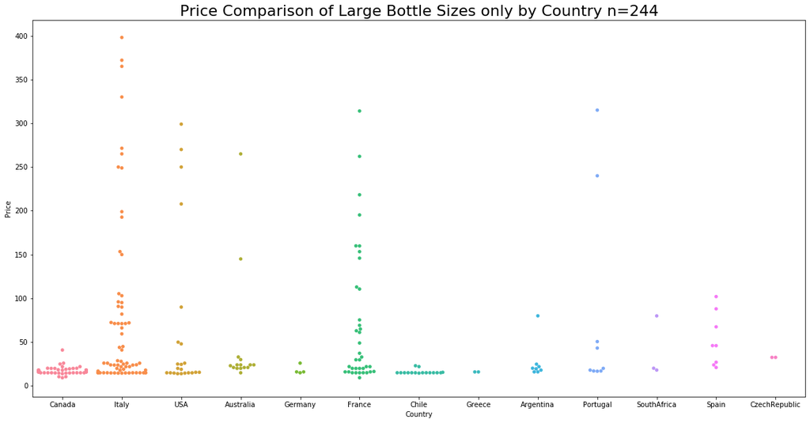

```python
plt.figure(figsize=(20, 10))
data=wine[wine['BottleCategorical']=='Large :>750ml']
sns.swarmplot(y='Price',x='Country',data=data)
plt.title('Price Comparison of Large Bottle Sizes only by Country n={}'.format(len(data)) , fontsize=22)
```

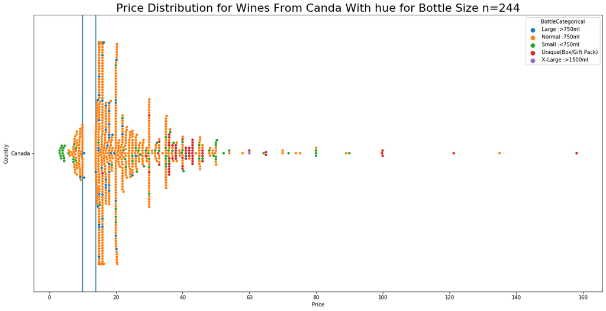

```python
plt.figure(figsize=(20, 10))
sns.swarmplot(x='Price',y='Country',data=wine[wine['Country']=='Canada'],hue='BottleCategorical')
plt.axvline(10, ls='-')
plt.axvline(14, ls='-')
plt.title('Price Distribution for Wines From Canda With hue for Bottle Size n={}'.format(len(data)) , fontsize=22)
```

### We can see an interesting discontinuity for for the price of wines between 10 and 14 dollars

# Part 4)

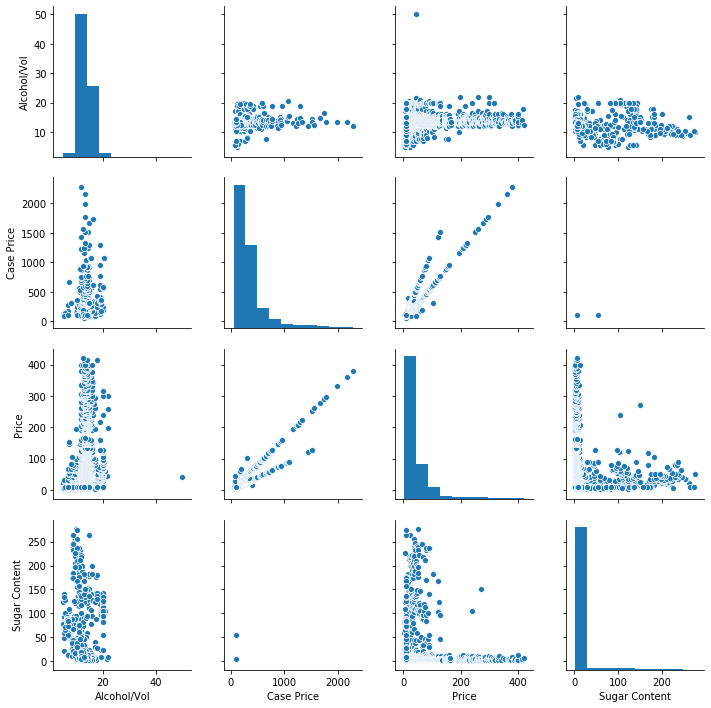

```python
sns.pairplot(wine)
```

### We saw before Price and Case Price had a Very strong relationship lets take a look at that

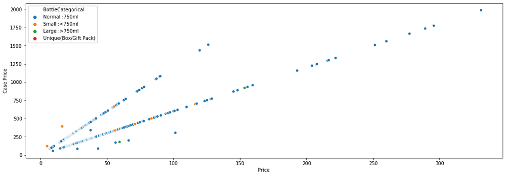

```python
plt.figure(figsize=(18,6))
data=wine[(wine['Case Price'].isna()==False) & (wine['Price']>=2) & (wine['Case Price']<=2000)]
sns.scatterplot(x='Price',y='Case Price',data=data,hue='BottleCategorical')
```

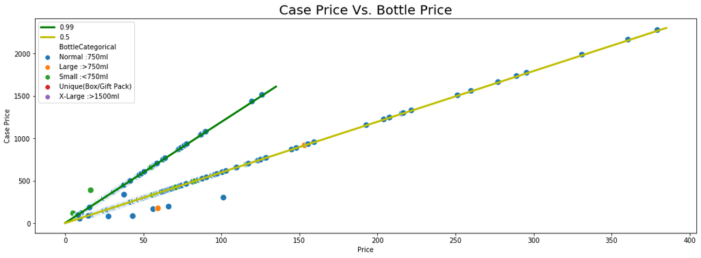

```python
plt.figure(figsize=(18,6))
sns.scatterplot(x='Price',data=wine,y='Case Price',s=90,hue='BottleCategorical').set_title('Case Price Vs. Bottle Price',fontsize=20)
plt.plot([0, 135], [6, 1610], linewidth=3,color='g',label=(round(((1610-6)/(135*12)),2)))
plt.plot([0, 385], [4, 2300], linewidth=3,color='y',label=round((2300-4)/(385*12),2))
plt.legend()
#sns.regplot(x='Price',data=wine,y='Case Price')
#we can see two distinct linear relationships between Case price and Price
```

### We can see above that there two distict linear relationships one where the case price is simply 12 times the price of a single bottle and the other at 6 times. Most likely due to a 12 pack and 6 pack case. That or a 50% discount

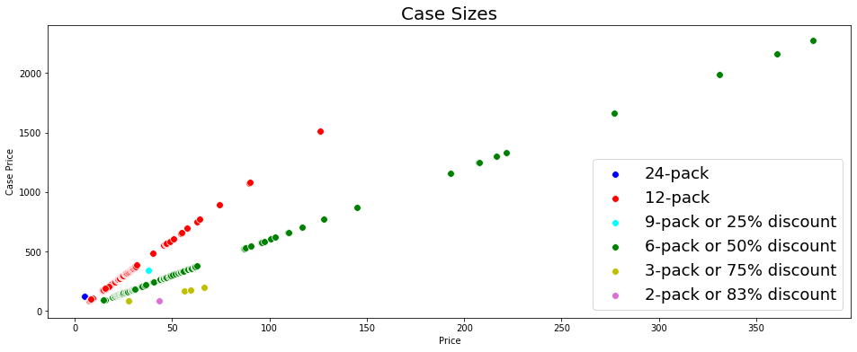

```python
plt.figure(figsize=(16,6))
sns.scatterplot(data=wine[wine['Case Price']==(24*wine['Price'])],y='Case Price',x='Price',color='b',label='24-pack',s=60)#
sns.scatterplot(data=wine[wine['Case Price']==(12*wine['Price'])],y='Case Price',x='Price',color='r',label='12-pack',s=60)#
sns.scatterplot(data=wine[wine['Case Price']==(9*wine['Price'])],y='Case Price',x='Price',color='cyan',label='9-pack or 25% discount',s=60)# use 11 to account for a 10% discount
sns.scatterplot(data=wine[wine['Case Price']==(6*wine['Price'])],y='Case Price',x='Price',color='g',label='6-pack or 50% discount',s=60)# use 11 to account for a 10% discount
sns.scatterplot(data=wine[wine['Case Price']==(3*wine['Price'])],y='Case Price',x='Price',color='y',label='3-pack or 75% discount',s=60)# use 11 to account for a 10% discount
sns.scatterplot(data=wine[wine['Case Price']==(2*wine['Price'])],y='Case Price',x='Price',color='orchid',label='2-pack or 83% discount',s=60).set_title('Case Sizes',fontsize=20)
plt.legend()
plt.legend(loc=4, prop={'size': 18}) # use best for legend placement and increase size
```

## We can see above the clear linear distinction between the different case prices and case sizes.

## Although the website did not state the case quantity it looks like there is no actuall discount offered for purchasing a case of wine versus the individual bottle. (Excluding the unlikely case of a 25%, 50%, or even 83% discount on the wine)

### Lets look at some distributions

```python
def show_wine(Var,X='Price',start=0,end=10,color='blue',hist=False,title='',interactive=False,colors=None):
    ''' PriceCountry(x,color='blue',hist=False,title='',interactive=False,colors=None):

    Retuns a plot of desiered variables #done for simplicity when ploting '''

    x=wine[Var].value_counts().index[start:end]

    if interactive == False:
        i=0
        if isinstance(x, str):#check if a list is passed or only one string variable
#
            pl=sns.distplot(wine[wine[Var]==Var][X],bins=15,kde=True,color='g',kde_kws=dict(linewidth=2)).set_title('{} distribution for {}'.format(X,Var))
            pl.legend(loc='best', prop={'size': 20}) # use best for legend placement and increase sizie
            pl.set(xlim=(0,100))


        else:
#             print('notStr')
            Colors=sns.color_palette("colorblind", len(x))
            for word in x:

                pl=sns.distplot(wine[wine[Var]==x[i]][X],bins=15,kde=True,hist=False,color=Colors[i],label=x[i],kde_kws=dict(linewidth=2))
                pl.legend(loc='best', prop={'size': 10}) # use best for legend placement and increase sizie
                i+=1
                pl.set_title('{} distribution for {}'.format(X,Var),fontsize=20)

    #Interactive = True
    else:
        if isinstance(x, str): #only one country

            hist_data=[wine[wine[Var]==x][y].tolist()]
            group_labels=[x]
            fig = ff.create_distplot(hist_data, group_labels,show_hist=True ,show_rug=False,colors=colors)
            fig.show()

        else: #list of countrys
           # filename=['examples/distplot with pandas']
            templist=[]
            emp=[]
            for word in x: templist.append(wine[wine[Var]==word][X])
            hist_data = templist
            for word in x: emp.append(word) # name of the dataset
            group_labels = emp


            fig = ff.create_distplot(hist_data,group_labels,show_hist=False ,show_rug=False,colors=colors)
            fig.layout=dict(title=dict(text='{} distribution for {}'.format(X,Var)))
            fig.show()


show_wine(Var='Country',X='Price',start=0,end=8,interactive=True)
```

[interactive chart not shown]

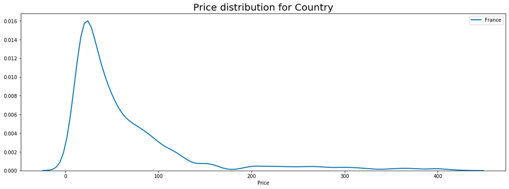

```python
plt.figure(figsize=(18,6))
show_wine(Var='Country',X='Price',start=0,end=1,interactive=False)
```

```python
show_wine(Var='Alcohol/Vol',X='Price',start=0,end=7,interactive=True)
```

[interactive chart not shown]

```python
show_wine(Var='Varietal',X='Price',start=0,end=10,interactive=True)
```

[interactive chart not shown]

```python
show_wine(Var='Varietal',X='Price',start=7,end=9,interactive=True)
```

[interactive chart not shown]

### Below on the first plot we can see the Alcohol distribution for Riesling which is known for its high acidity and ability to make great sweet low alcohol wines

### On the second plot we can see the outlying distribution of the fortified port wine

```python
show_wine(Var='Varietal',X='Alcohol/Vol',start=0,end=8,interactive=True)
```

[interactive chart not shown]

```python
show_wine(Var='Varietal',X='Alcohol/Vol',start=25,end=40,interactive=True)
```

[interactive chart not shown]

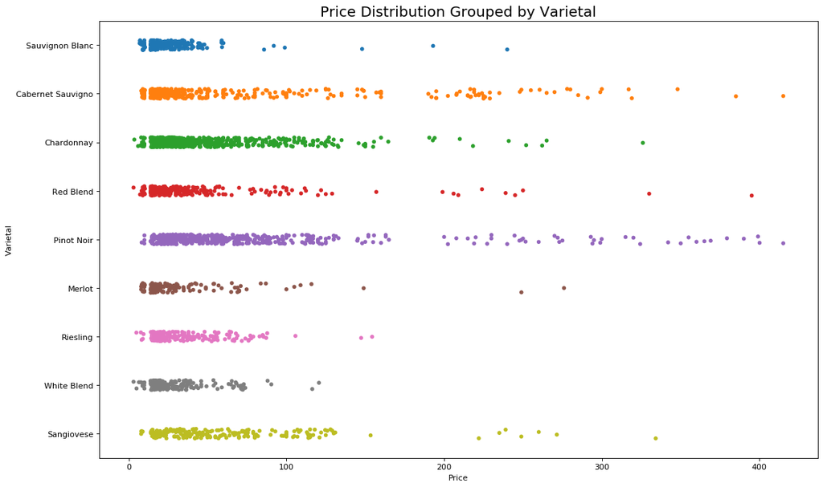

```python
fig, ax = plt.subplots(figsize=(16,10), dpi= 80)
# Decorations
plt.title('Price Distribution Grouped by Varietal', fontsize=18)
topwine=wine[(wine['Varietal']=='Chardonnay') | (wine['Varietal']=='Pinot Noir')| (wine['Varietal']=='Cabernet Sauvigno')
            | (wine['Varietal']=='Sauvignon Blanc')| (wine['Varietal']=='Red Blend')| (wine['Varietal']=='CShiraz/Syrah')
            | (wine['Varietal']=='Riesling')| (wine['Varietal']=='Sangiovese')| (wine['Varietal']=='White Blend')
            | (wine['Varietal']=='Merlot')]
sns.stripplot(y='Varietal', x='Price', data=topwine)
```

### We can also take a closer look at the style and sugar content

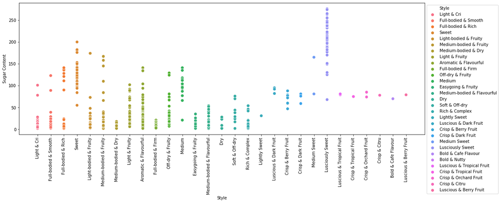

```python
plt.figure(figsize=(18,6))
sns.scatterplot(x='Style',y='Sugar Content',hue='Style',data=wine,s=60)
plt.xticks(rotation=90)
plt.legend(bbox_to_anchor=(1, 1), loc=2)
plt.show()
#plt.legend().remove()
```

[output not shown]

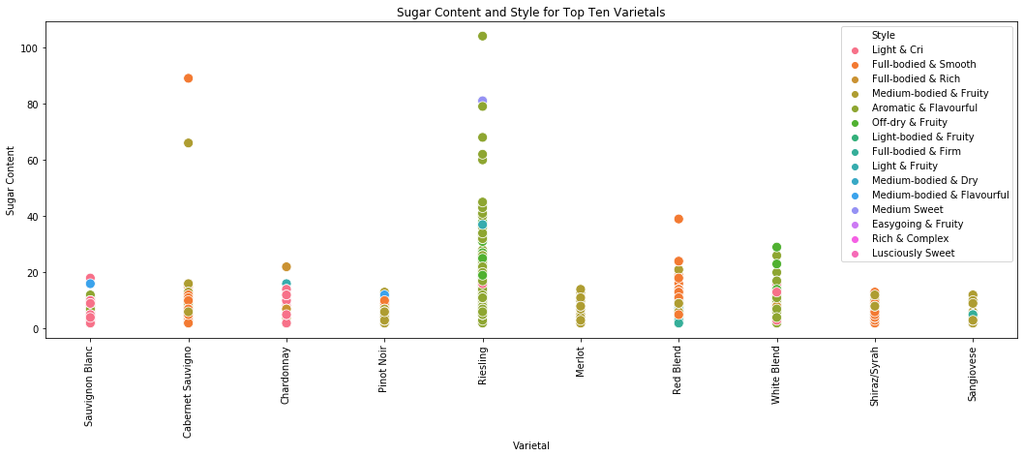

```python
plt.figure(figsize=(18,6))
sns.scatterplot(x='Varietal',y='Sugar Content',hue='Style',data=wine[wine['Varietal'].isin(top10)],s=100).set_title('Sugar Content and Style for Top Ten Varietals')
plt.xticks(rotation=90)
#plt.legend().remove()
```

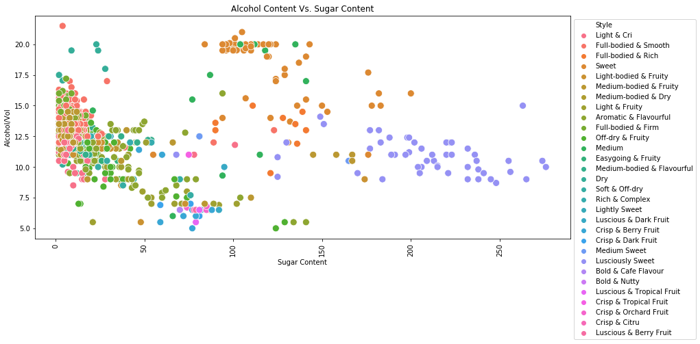

```python
plt.figure(figsize=(14,6))
sns.scatterplot(x='Sugar Content',y='Alcohol/Vol',hue='Style',data=wine,s=100).set_title('Alcohol Content Vs. Sugar Content')
plt.xticks(rotation=90)
plt.legend(bbox_to_anchor=(1, 1), loc=2)

#plt.legend().remove()
```

### We can see above we have some nice grouping of different wine styles based on Alcohol and Sugar Content

### Finally lets add a Search Function for the data frame

```python
def find_wine_in(column,word):
    return wine[wine[column].str.contains(word)==True]
find_wine_in(column='Product_Name',word='Icewine').head()
```

|  | Alcohol/Vol | Bottle Size | By | Case Price | Made In | Price | Product_Name | Release Date | Style | Sugar Content | Sweetness Descriptor | Varietal | Region | Country | BottleCategorical |
| --- | --- | --- | --- | --- | --- | --- | --- | --- | --- | --- | --- | --- | --- | --- | --- |
| 2267 | 11.00 | 200 | Pondview Estate Winery Ltd. | NaN | Ontario, Canada | 19.95 | Pondview Gold Series Vidal Icewine 2015 | May 11, 2019 | Lusciously Sweet | 220.0 | S - Sweet | Vidal | Ontario | Canada | Small :<750ml |
| 2343 | 17.18 | 375 | Magnotta Winery | NaN | Canada | 19.95 | Kittling Ridge Icewine & Brandy | NaN | Sweet | 124.0 | S - Sweet | Dessert Wine | NaN | Canada | Small :<750ml |
| 2469 | 10.50 | 200 | Palatine Hills Estate | NaN | Ontario, Canada | 19.95 | Palatine Hills Vidal Icewine 2012 | May 25, 2019 | Lusciously Sweet | 213.0 | S - Sweet | Vidal | Ontario | Canada | Small :<750ml |
| 2918 | 12.00 | 200 | Lakeview Cellars Estate Winery | NaN | Ontario, Canada | 21.95 | Lakeview Cellars Vidal Icewine | April 3, 2019 | Lusciously Sweet | 202.0 | S - Sweet | Icewine | Ontario | Canada | Small :<750ml |
| 3109 | 9.00 | 200 | Inniskillin House Wines Inc | NaN | Ontario, Canada | 22.75 | Inniskillin Vidal Icewine | NaN | NaN | NaN | NaN | Vidal | Ontario | Canada | Small :<750ml |

## Thanks for taking the time to check out my project and reading all the way to the bottom